# Mushroom Classification

Mosaab Muhammad  
August 10th, 2019

## I. Definition

### Project Overview

#### Project Origin:

This problem is taken from **Kaggle**, named as [Mushroom Classification](https://www.kaggle.com/uciml/mushroom-classification), and collected by **UCI Machine Learning**.

#### Problem Domain:

Before delving into the problem, let me introduce you to the problem domain, which is related to mushroom classification, to determine whether it's *poisonous* or *edible*.  
Since the collected data shows the mushroom features, let me make them crisp and clear for you, to be able to understand the big picture.  
I'll start by an image, showing the most important features for mushroom:

[figure not shown]

From the image, we can say that we have 5 main features of the mushroom:

1. **Cap:** which is the top part of the mushroom from above, which takes the umberlla shape.
2. **Gill:** which is the underside of the cap
3. **Ring:** which is this little shape that surround the stem (stalk).
4. **Stalk (Stem):** is what makes the mushroom standing, it's this vertical cylindrical.
5. **Veil (Volva):** which is the bottom shape of the mushroom, that covers the bottom part of the mushroom.

There are other features that is included in the dataset, such as:

- **Bruises**: Does the mushroom has bruises or not.
- **Spore Print Color**: Shows the color of the mushroom spores if viewed en masse. The image below shows how it looks like.[[1]](https://en.wikipedia.org/wiki/Spore_print)
- **Oder**: Desribes the smell or the odor of the mushroom.
- **Population**: Shows what kind of populations that this mushroom grows.
- **Habitat**: Shows where it lives.

[figure not shown]

#### Attribute Information:

Now, let's look at the attributes of dataset, to know if we can understand now or not:

- **classes:** edible=e, poisonous=p

#### Features related to `Cap`:

- **cap-shape:** bell=b, conical=c, convex=x, flat=f, knobbed=k, sunken=s
- **cap-surface:** fibrous=f, grooves=g, scaly=y, smooth=s
- **cap-color:** brown=n,buff=b,cinnamon=c,gray=g,green=r,pink=p,purple=u,red=e,white=w,yellow=y

#### Features related to `Gill`:

- **gill-attachment:** attached=a, descending=d, free=f, notched=n
- **gill-spacing:** close=c, crowded=w, distant=d
- **gill-size:** broad=b, narrow=n
- **gill-color:** black=k, brown=n, buff=b, chocolate=h, gray=g, green=r, orange=o, pink=p, purple=u, red=e, white=w, yellow=y

#### Features related to `Stalk`:

- **stalk-shape:** enlarging=e,tapering=t
- **stalk-root:** bulbous=b,club=c,cup=u,equal=e,rhizomorphs=z,rooted=r,missing=?
- **stalk-surface-above-ring:** fibrous=f,scaly=y,silky=k,smooth=s
- **stalk-surface-below-ring:** fibrous=f,scaly=y,silky=k,smooth=s
- **stalk-color-above-ring:** brown=n,buff=b,cinnamon=c,gray=g,orange=o,pink=p,red=e,white=w,yellow=y
- **stalk-color-below-ring:** brown=n,buff=b,cinnamon=c,gray=g,orange=o,pink=p,red=e,white=w,yellow=y

#### Features related to `Veil`:

- **veil-type:** partial=p,universal=u
- **veil-color:** brown=n,orange=o,white=w,yellow=y
- **ring-number:** none=n,one=o,two=t
- **ring-type:** cobwebby=c,evanescent=e,flaring=f,large=l,none=n,pendant=p,sheathing=s,zone=z

#### `Misc` Features:

- **bruises:** bruises=t,no=f
- **odor:** almond=a,anise=l,creosote=c,fishy=y,foul=f,musty=m,none=n,pungent=p,spicy=s
- **spore-print-color:** black=k,brown=n,buff=b,chocolate=h,green=r,orange=o,purple=u,white=w,yellow=y
- **population:** abundant=a,clustered=c,numerous=n,scattered=s,several=v,solitary=y
- **habitat:** grasses=g,leaves=l,meadows=m,paths=p,urban=u,waste=w,woods=d

### Problem Statement

Our task here, is to be able to classify the mushroom whether it's *edible* or *poisionous* (Binary Classification), based on the given features.  
Here's some inspirational questions, that I'm going to discover:

- What types of machine learning models perform best on this dataset?
- Which features are most indicative of a poisonous mushroom?
- Which features are most indicative of a edible mushroom?

**Point of View:** In my opinion, the last 2 questions are very important, because as a layman, he can take a look at the mushroom and determine whether it's edible or poisonous, I know, It's not that easy and it's very tricky to determine between them, but at least we can make a better decision based on data better than a decision based on nothing.

### Metrics

- Since we are concered about **Type II Error**, (false-negatives), meaning we don't want to say about the poisouous mushroom that it's safe, so I'm going to measure how well the predictions are based on the `Recall`.
- For this project, I'm going to use `Accuracy` to measure how well the prediction of the model is.
- For some reason, I'm going to use `ROC_AUC` Curve to measure how well the model is.

### Project Steps

- Import Libraries & Read Data:
- Explore the data:
  - I'll try a bar chart with each feature and how it relates to class/target feature.
- Preprocess the data:
  - Create dummy variables for each column.
  - Use PCA or t-SNE to reduce the number of dimensions.
  - ...
- Model the data:
  - Benchmark.
  - ...
- Evaluation:
  - ...
- Summary:
  - ...

## II. Analysis

### Import Libraries

```python
import numpy as np
import pandas as pd
import matplotlib.pyplot as plt
import matplotlib as mlt
import seaborn as sns

# Warnings
import warnings
warnings.filterwarnings('ignore')
```

```python
%matplotlib inline
%precision 3
plt.style.use('ggplot')
sns.set_style('white')
```

### Read Data

```python
df_origin = pd.read_csv('./mushrooms.csv')
df = df_origin.copy()
```

```python
df.sample(6)
```

|  | class | cap-shape | cap-surface | cap-color | bruises | odor | gill-attachment | gill-spacing | gill-size | gill-color | ... | stalk-surface-below-ring | stalk-color-above-ring | stalk-color-below-ring | veil-type | veil-color | ring-number | ring-type | spore-print-color | population | habitat |
| --- | --- | --- | --- | --- | --- | --- | --- | --- | --- | --- | --- | --- | --- | --- | --- | --- | --- | --- | --- | --- | --- |
| 3476 | e | f | f | g | t | n | f | c | b | u | ... | s | g | g | p | w | o | p | n | y | d |
| 2527 | e | x | y | n | t | n | f | c | b | w | ... | s | w | w | p | w | o | p | k | y | d |
| 1353 | e | f | s | n | f | n | f | w | b | k | ... | f | w | w | p | w | o | e | n | a | g |
| 5455 | p | x | y | y | f | f | f | c | b | g | ... | k | n | p | p | w | o | l | h | y | g |
| 7523 | e | f | s | n | f | n | a | c | b | o | ... | s | o | o | p | o | o | p | n | c | l |
| 4315 | p | f | f | g | f | f | f | c | b | p | ... | k | b | p | p | w | o | l | h | v | g |

6 rows × 23 columns

```python
df.info()
```

```
<class 'pandas.core.frame.DataFrame'>
RangeIndex: 8124 entries, 0 to 8123
Data columns (total 23 columns):
class                       8124 non-null object
cap-shape                   8124 non-null object
cap-surface                 8124 non-null object
cap-color                   8124 non-null object
bruises                     8124 non-null object
odor                        8124 non-null object
gill-attachment             8124 non-null object
gill-spacing                8124 non-null object
gill-size                   8124 non-null object
gill-color                  8124 non-null object
stalk-shape                 8124 non-null object
stalk-root                  8124 non-null object
stalk-surface-above-ring    8124 non-null object
stalk-surface-below-ring    8124 non-null object
stalk-color-above-ring      8124 non-null object
stalk-color-below-ring      8124 non-null object
veil-type                   8124 non-null object
veil-color                  8124 non-null object
ring-number                 8124 non-null object
ring-type                   8124 non-null object
spore-print-color           8124 non-null object
population                  8124 non-null object
habitat                     8124 non-null object
dtypes: object(23)
memory usage: 1.4+ MB
```

```python
# Let's see the shape of our dataframe
print("Shape of the data =", df.shape)
```

```
Shape of the data = (8124, 23)
```

#### Observation:

Since all the columns are `Categorical`, and we have 23 columns. We need to dummy those columns and use PCA or t-SNE to reduce those columns.

### Descriptive Statistics:

```python
df.describe(include='all')
```

|  | class | cap-shape | cap-surface | cap-color | bruises | odor | gill-attachment | gill-spacing | gill-size | gill-color | ... | stalk-surface-below-ring | stalk-color-above-ring | stalk-color-below-ring | veil-type | veil-color | ring-number | ring-type | spore-print-color | population | habitat |
| --- | --- | --- | --- | --- | --- | --- | --- | --- | --- | --- | --- | --- | --- | --- | --- | --- | --- | --- | --- | --- | --- |
| count | 8124 | 8124 | 8124 | 8124 | 8124 | 8124 | 8124 | 8124 | 8124 | 8124 | ... | 8124 | 8124 | 8124 | 8124 | 8124 | 8124 | 8124 | 8124 | 8124 | 8124 |
| unique | 2 | 6 | 4 | 10 | 2 | 9 | 2 | 2 | 2 | 12 | ... | 4 | 9 | 9 | 1 | 4 | 3 | 5 | 9 | 6 | 7 |
| top | e | x | y | n | f | n | f | c | b | b | ... | s | w | w | p | w | o | p | w | v | d |
| freq | 4208 | 3656 | 3244 | 2284 | 4748 | 3528 | 7914 | 6812 | 5612 | 1728 | ... | 4936 | 4464 | 4384 | 8124 | 7924 | 7488 | 3968 | 2388 | 4040 | 3148 |

4 rows × 23 columns

**Since in this dataset, the `veil-type` has only one value for each row, so I'm going to remove it.**

```python
del df['veil-type']
```

Let's see if the class column is balanced or not

```python
df['class'].value_counts().to_frame().style.background_gradient('summer')

# Looks like we have a balanced dataset.
```

|  | class |
| --- | --- |
| e | 4208 |
| p | 3916 |

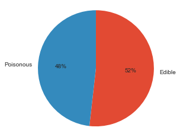

```python
sorted_counts = df['class'].value_counts()
plt.pie(sorted_counts, labels=['Edible', 'Poisonous'], startangle=90, counterclock=False, autopct='%1.0f%%')
plt.axis('square');
```

## Exploratory Data Analysis (EDA)

In order to answer the first 2 questions, I'll take features one by one and see how it relates to the target class.

**Let's start with `Cap` Features:** [`cap-shape`, `cap-surface`, `cap-color`]

```python
# First, I'll change the label for each column instead of a letter to a word, just for the sake of visualization,
# then I'll return it back, in the data preprocessing.
df_visual = df.copy()

cap_shape = dict(b='bell', c='conical', x='convex', f='flat', k='knobbed', s='sunken')
cap_surface = dict(f='fibrous', g='grooves', y='scaly', s='smooth')
cap_color = dict(n='brown', b='buff', c='cinnamon', g='gray', r='green', p='pink', u='purple', e='red', w='white', y='yellow')

df_visual['cap-shape'] = df_visual['cap-shape'].map(cap_shape)
df_visual['cap-surface'] = df_visual['cap-surface'].map(cap_surface)
df_visual['cap-color'] = df_visual['cap-color'].map(cap_color)
```

```python
df_visual['class'] = df_visual['class'].map(dict(p='Poisonous', e='Edible'))
```

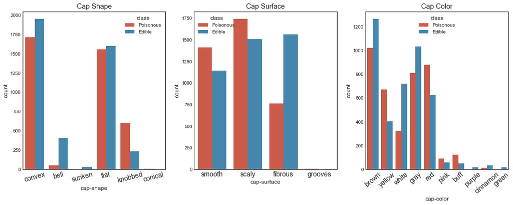

```python
plt.figure(figsize=(18, 6))
plt.subplot(131)
sns.countplot(x='cap-shape', data=df_visual, hue='class')
plt.title('Cap Shape')
plt.xticks(rotation=15)

plt.subplot(132)
sns.countplot(x='cap-surface', data=df_visual, hue='class')
plt.title('Cap Surface')

plt.subplot(133)
sns.countplot(x='cap-color', data=df_visual, hue='class');
plt.title('Cap Color')
plt.xticks(rotation=40)
mlt.rc('xtick', labelsize=14)

plt.subplots_adjust(wspace=.2)
```

#### Observation:

**NOTE:**

**Let's take the `Gill` Feature, and see how we can get anything from it:** [`gill-attachment`, `gill-spacing`, `gill-size`, `gill-color`]

```python
# changing the label for each column instead of a letter to a word, just for the sake of visualization.

gill_attachment = dict(a='Attached', d='Descending', f='Free', n='Notched')
gill_spacing = dict(c='Close', w='Crowded', d='Distant')
gill_size = dict(b='Broad', n='Narrow')
gill_color = dict(n='Brown', b='Buff', g='Gray', r='Green', p='Pink', u='Purple', o='Orange',
                  h='Chocolate', k='Black', e='Red', w='White', y='Yellow')

df_visual['gill-attachment'] = df_visual['gill-attachment'].map(gill_attachment)
df_visual['gill-spacing'] = df_visual['gill-spacing'].map(gill_spacing)
df_visual['gill-size'] = df_visual['gill-size'].map(gill_size)
df_visual['gill-color'] = df_visual['gill-color'].map(gill_color)
```

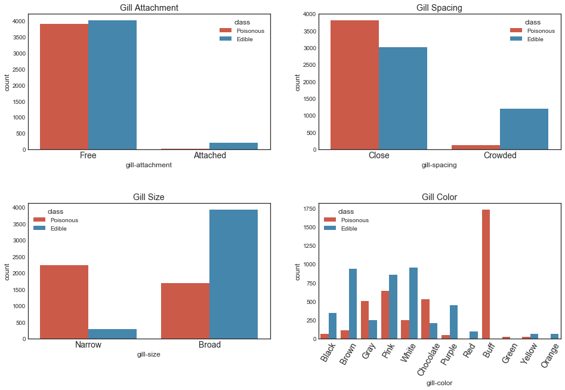

```python
plt.figure(figsize=(16, 10))

plt.subplot(221)
sns.countplot(data=df_visual, x='gill-attachment', hue='class')
plt.title('Gill Attachment')

plt.subplot(222)
sns.countplot(data=df_visual, x='gill-spacing', hue='class')
plt.title('Gill Spacing')

plt.subplot(223)
sns.countplot(data=df_visual, x='gill-size', hue='class')
plt.title('Gill Size')

plt.subplot(224)
sns.countplot(data=df_visual, x='gill-color', hue='class')
plt.title('Gill Color')
plt.xticks(rotation=60)
mlt.rc('xtick', labelsize=12)


plt.subplots_adjust(wspace=.2, hspace=.4)
```

#### Observations:

- `Gill Attachment`:
  - If it's `Attached`, it's mostly safe, but it's hard to tell.
  - If it's `Free`, it doesn't add up much information.
- `Gill Spacing`:
  - If it's `Crowded`, then it's mostly edible.
  - It would be much safer, if you found mushroom with `Close Gill Spacing`, and didn't eat it.
- `Gill Size`:
  - If it's `Narrow`, then it's mostly poisonous.
  - If it's `Broad`, then it's mostly safe to eat, but take care.
- `Gill Color`:
  - The most poisonous color for gill mushroom is `Buff`, it's not safe at all.
  - The most safer color for gill is `Brown`, `White`, `Black`, and `Purple`.
  - It's hard to tell that `Orange`, `Red`, and `Yellow`, because we have a few data of them.

**Let's take the `Stalk` Feature, and see how it relates to edible or poisonous:** [`stalk-shape`, `stalk-root`, `stalk-surface-above-ring`, `stalk-surface-below-ring`, `stalk-color-above-ring`, `stalk-color-below-ring`]

```python
# changing the label for each column instead of a letter to a word, just for the sake of visualization.
stalk_shape              = dict(e='enlarging',t='tapering')
stalk_root               = {'b':'bulbous','c':'club','u':'cup','e':'equal','z':'rhizomorphs','r':'rooted', '?':'missing'}
stalk_surface_above_ring = dict(f='fibrous',y='scaly',k='silky',s='smooth')
stalk_surface_below_ring = dict(f='fibrous',y='scaly',k='silky',s='smooth')
stalk_color_above_ring   = dict(n='brown', b='buff', c='cinnamon', g='gray', o='orange', p='pink', e='red',
                                w='white', y='yellow')
stalk_color_below_ring   = dict(n='brown', b='buff', c='cinnamon', g='gray', o='orange', p='pink', e='red',
                                w='white', y='yellow')

# Map all the new labels to its corresponding column
df_visual['stalk-shape']              = df_visual['stalk-shape'].map(stalk_shape)
df_visual['stalk-root']               = df_visual['stalk-root'].map(stalk_root)
df_visual['stalk-surface-above-ring'] = df_visual['stalk-surface-above-ring'].map(stalk_surface_above_ring)
df_visual['stalk-surface-below-ring'] = df_visual['stalk-surface-below-ring'].map(stalk_surface_below_ring)
df_visual['stalk-color-above-ring']   = df_visual['stalk-color-above-ring'].map(stalk_color_above_ring)
df_visual['stalk-color-below-ring']   = df_visual['stalk-color-below-ring'].map(stalk_color_below_ring)
```

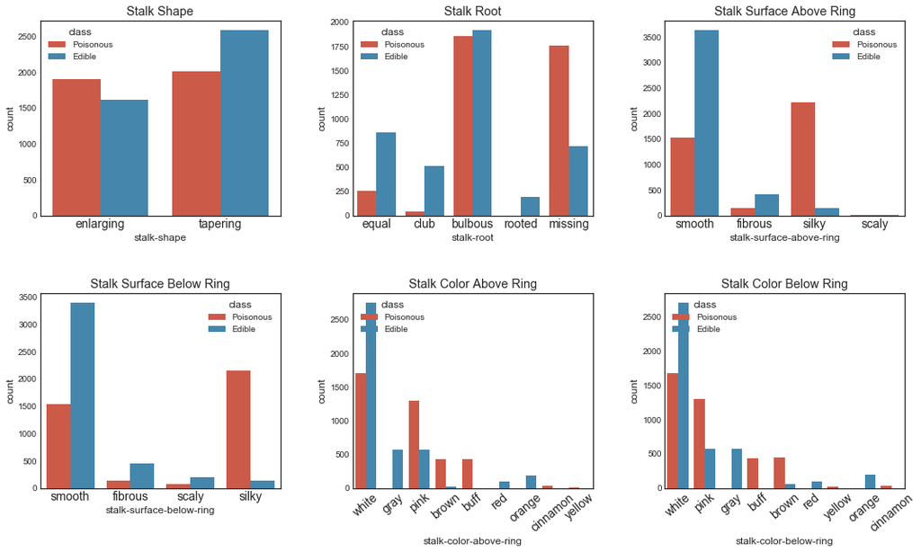

```python
plt.figure(figsize=(18, 10))

plt.subplot(231)
sns.countplot(data=df_visual, x='stalk-shape', hue='class')
plt.title('Stalk Shape')

plt.subplot(232)
sns.countplot(data=df_visual, x='stalk-root', hue='class')
plt.title('Stalk Root')

plt.subplot(233)
sns.countplot(data=df_visual, x='stalk-surface-above-ring', hue='class')
plt.title('Stalk Surface Above Ring')


plt.subplot(234)
sns.countplot(data=df_visual, x='stalk-surface-below-ring', hue='class')
plt.title('Stalk Surface Below Ring')


plt.subplot(235)
sns.countplot(data=df_visual, x='stalk-color-above-ring', hue='class')
plt.title('Stalk Color Above Ring')
plt.xticks(rotation=40)

plt.subplot(236)
sns.countplot(data=df_visual, x='stalk-color-below-ring', hue='class')
plt.title('Stalk Color Below Ring')
plt.xticks(rotation=40)
mlt.rc('xtick', labelsize=14)

plt.subplots_adjust(wspace=.3, hspace=.4)
```

#### Observations:

- `Stalk Root`:
  - If the root is equal, club, or rooted, then it's mostly safe.
- `Stalk Surface`:
  - There are more safe mushrooms that has smooth stalk surface, than the poisnous ones.
- `Stalk Color`:
  - The more safer color for stalk is `White` and `Gray`.
  - The `Orange` is hard to tell, whether it's safe or not, since it has fewer records.
  - The most dangerous colors is `pink`, `buff`, and `brown`.

**Let's take the `Veil` and `Ring` Features, and see how it relates to edible or poisonous:** [`veil-type`, `veil-color`, `ring-number`, `ring-type`]

```python
# changing the label for each column instead of a letter to a word, just for the sake of visualization.

veil_color  = dict(n='brown', o='orange', w='white', y='yellow')
ring_number = dict(n='none', o='one', t='two')
ring_type   = dict(c='cobwebby', e='evanescent', f='flaring', l='large', n='none', p='pendant',
                   s='sheathing', z='zone')

df_visual['veil-color']  = df_visual['veil-color'].map(veil_color)
df_visual['ring-number'] = df_visual['ring-number'].map(ring_number)
df_visual['ring-type']   = df_visual['ring-type'].map(ring_type)
```

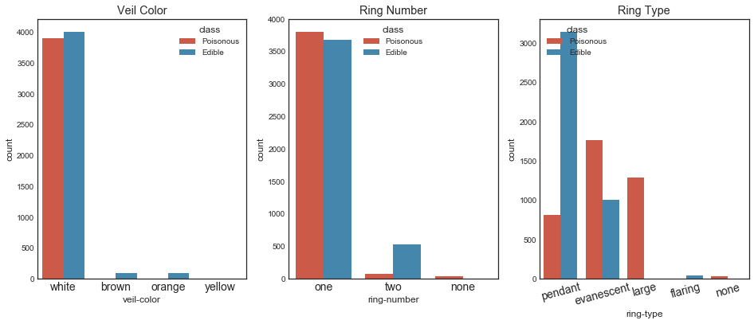

```python
plt.figure(figsize=(16, 6))

plt.subplot(131)
sns.countplot(data=df_visual, x='veil-color', hue='class')
plt.title('Veil Color')

plt.subplot(132)
sns.countplot(data=df_visual, x='ring-number', hue='class')
plt.title('Ring Number')

plt.subplot(133)
sns.countplot(data=df_visual, x='ring-type', hue='class')
plt.title('Ring Type')
plt.xticks(rotation=15)
mlt.rc('xtick', labelsize=12)


plt.subplots_adjust(wspace=.2, hspace=.4)
```

#### Observations:

- `veil-color`:
  - This feature doesn't tell us much, since `Orange` and `Brown` are edible, but we have a fewer records to build a verdit based on it.
- `ring-number`:
  - It the mushroom has 2 rings, it's likely to be safe.
- `ring-type`:
  - If the mushroom has ring with type `Pendant` or `flaring`, then it's most likely to be edible.
  - If the mushroom has ring with type `evanescent` or `large`, then it's most likely to be poisonous.

**Time for the `Misc` Features: [`bruises`, `odor`, `spore-print-color`, `population`, `habitat`]**

```python
bruises           = dict(t='true', f='false')
odor              = dict(a='almond', l='anise', c='creosote', y='fishy', f='foul', m='musty', n='none',
                         p='pungent', s='spicy')
spore_print_color = dict(k='black', n='brown', b='buff', h='chocoloate', r='green', o='Orange', u='Purple',
                        w='White', y='Yellow')
population        = dict(a='Abundant', c='Clustered', n='Numerous', s='Scattered', v='Several', y='Solitary')
habitat           = dict(g='Grasses', l='Leaves', m='Meadows', p='Paths', u='Urban', w='Waste', d='Woods')


df_visual['bruises']             = df_visual['bruises'].map(bruises)
df_visual['odor']                = df_visual['odor'].map(odor)
df_visual['spore-print-color']   = df_visual['spore-print-color'].map(spore_print_color)
df_visual['population']          = df_visual['population'].map(population)
df_visual['habitat']             = df_visual['habitat'].map(habitat)
```

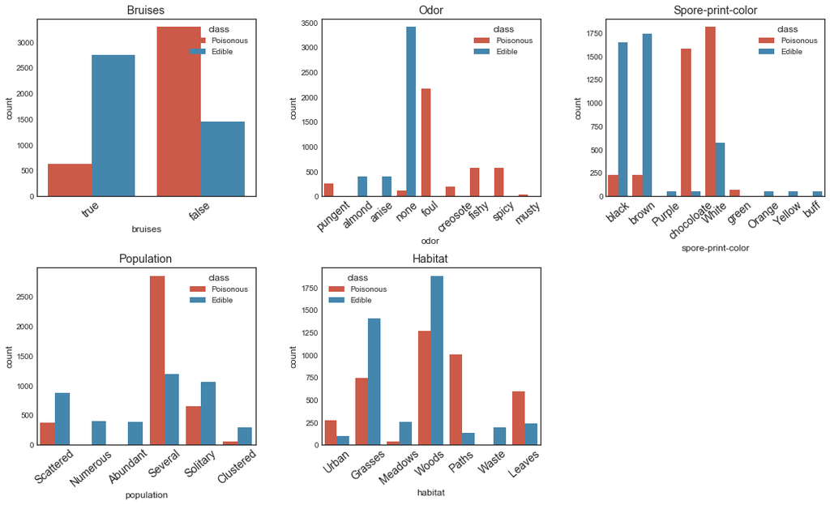

```python
plt.figure(figsize=(18, 10))

labels = ['bruises', 'odor', 'spore-print-color', 'population', 'habitat']

for i, label in enumerate(labels):
    plt.subplot(2, 3, i+1)
    sns.countplot(data=df_visual, x=label, hue='class')
    plt.title(label.capitalize())
    plt.xticks(rotation=40)

mlt.rc('xtick', labelsize=14)
plt.subplots_adjust(wspace=.3, hspace=.4)
```

#### Observations:

- `Bruises`:
  - It the mushroom has bruises, it's most likey to be edible, and vice versa.
- `Odor`:
  - If the mushroom has no smell, or the smell of `Almond` or `Anise`, then it's edible.
  - If the mushroom has the smell of `Pungent`, `foul`, `creosote`, `fishy`, `spicy`, or `musty`, then it's poisonous.
- `Spore Print Color`:
  - If the color is `Black` or `Brown`, then it's most likely to be edible.
  - If the color is `Chocoloate` or `White`, then it's most likely to be poisonous.
  - For the colors `Purple`, `Orange`, `Yellow`, `Buff`, or `Green`, we don't have enough records to build a verdit.
- `Population`:
  - If it's `Numerous` or `Abundant`, then it's edible.
  - If it's `Scattered` or `Solitary`, then it's most likely to be edible.
  - If it's `Several`, then it's most likely to be poisonous.
- `Habitat`:
  - It's most likely to be edible, if the habitat of the mushroom is `Grasses`, `Woods`, or `Waste`.
  - It's most likely to be poisonous, if the habitat of the mushroom is `Paths`, `Leaves`, or `Urban`.

#### NOTE:

From the observations above, you noticed that most of them are wrote using `IF` condition, which means that we can build a model, which likely to be a decision tree to make a prediction based on those conditions for each feature.

## III. Methodology

### Data Preprocessing

Since we have 21 features and every feature in that 21 features is *categorical*, then I'm going to use dummy variable to convert these features into numerical features, and as a result, the number of columns will increase based how unique values in each feature.

Then to reduce those n features, I'm going to use PCA and t-SNE (which is the state-of-the-art in reducing dimensionality).

After reducing some dimensionalities, I'm going to fit those new features to the models, and see which one gives best results.

### Dummy Variables:

```python
# Splite the featuers and target in two variables.
X = df.drop('class', axis=1)
y = df['class']

# For the sake of visualization, then I'll return it by hot-encoding.
y = y.map({'p': 'Posionous', 'e': 'Edible'})

print('Shape of X =', X.shape)
print('Shape of y =', y.shape)
```

```
Shape of X = (8124, 21)
Shape of y = (8124,)
```

```python
# Get dummy variables for each column in X.
X_dummy = pd.get_dummies(X, drop_first=True)
X_dummy.sample(5)
```

|  | cap-shape_c | cap-shape_f | cap-shape_k | cap-shape_s | cap-shape_x | cap-surface_g | cap-surface_s | cap-surface_y | cap-color_c | cap-color_e | ... | population_n | population_s | population_v | population_y | habitat_g | habitat_l | habitat_m | habitat_p | habitat_u | habitat_w |
| --- | --- | --- | --- | --- | --- | --- | --- | --- | --- | --- | --- | --- | --- | --- | --- | --- | --- | --- | --- | --- | --- |
| 5579 | 0 | 0 | 0 | 0 | 1 | 0 | 0 | 1 | 0 | 0 | ... | 0 | 0 | 1 | 0 | 0 | 0 | 0 | 0 | 0 | 0 |
| 1728 | 0 | 0 | 0 | 0 | 1 | 0 | 0 | 1 | 0 | 0 | ... | 0 | 1 | 0 | 0 | 1 | 0 | 0 | 0 | 0 | 0 |
| 768 | 0 | 0 | 0 | 0 | 0 | 0 | 0 | 1 | 0 | 0 | ... | 0 | 1 | 0 | 0 | 0 | 0 | 1 | 0 | 0 | 0 |
| 7406 | 0 | 0 | 1 | 0 | 0 | 0 | 0 | 1 | 0 | 1 | ... | 0 | 0 | 1 | 0 | 0 | 1 | 0 | 0 | 0 | 0 |
| 1464 | 0 | 0 | 0 | 0 | 1 | 0 | 0 | 0 | 0 | 0 | ... | 0 | 1 | 0 | 0 | 1 | 0 | 0 | 0 | 0 | 0 |

5 rows × 95 columns

**We can see now that we have 95 columns**

```python
print('Number of columns generated from dummy variables =', len(X_dummy.columns.values),'Columns')
```

```
Number of columns generated from dummy variables = 95 Columns
```

### PCA:

I'm going to convert the columns from 95 to 2 columns just for the sake of visualization.

Then I'm going to see how many columns contain most of the data, to train our model.

**And of course, before using PCA, we need to Standardize our data.**

```python
from sklearn.preprocessing import StandardScaler
from sklearn.decomposition import PCA
```

```python
X_std = StandardScaler().fit_transform(X_dummy)
X_std
```

```
array([[-0.022, -0.796, -0.337, ..., -0.405,  4.591, -0.156],
       [-0.022, -0.796, -0.337, ..., -0.405, -0.218, -0.156],
       [-0.022, -0.796, -0.337, ..., -0.405, -0.218, -0.156],
       ...,
       [-0.022,  1.256, -0.337, ..., -0.405, -0.218, -0.156],
       [-0.022, -0.796,  2.968, ..., -0.405, -0.218, -0.156],
       [-0.022, -0.796, -0.337, ..., -0.405, -0.218, -0.156]])
```

```python
# Reduce 95 features to 2 features to visualize it.
X_pca = PCA(n_components=2).fit_transform(X_std)

print('Original Number of features =',  X_dummy.shape[1] ,'columns')
print('Reduced Number of features =', X_pca.shape[1], 'columns')
```

```
Original Number of features = 95 columns
Reduced Number of features = 2 columns
```

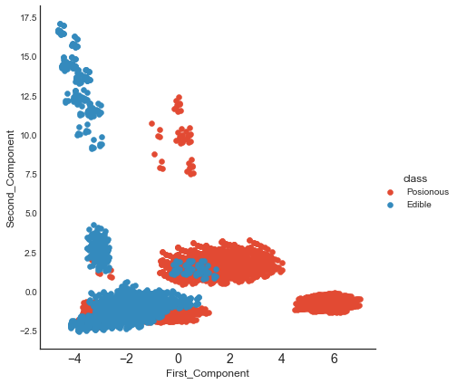

```python
# Attach the label for each 2-d data point
X_pca = np.vstack((X_pca.T, y)).T

df_pca = pd.DataFrame(X_pca, columns=['First_Component',
                                      'Second_Component',
                                      'class'])
sns.FacetGrid(data=df_pca, hue='class', size=6)\
   .map(plt.scatter, 'First_Component', 'Second_Component')\
   .add_legend();
```

#### Observations:

As we can see here, that PCA did fairly a poor job, distinguishing between 2 clusters, because there's a lot of overlapping between the 2 clusters, I know some of them are clustered well, but we're looking here to get the best prediction.

When we increase the number of principle component, PCA will do a better job distinguishing between them and reduce the overlapping between them, but unfortunatly we won't be able to visualize.

**Now, let's see how many number of features has the 97% of the data, to fit our model with it?**

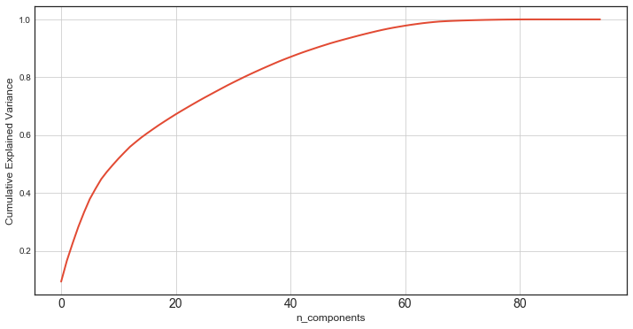

```python
# I'll create a CDF for number of features, to answer that question
pca = PCA(n_components=95)
X_pca = pca.fit_transform(X_std)

percent_var_explained = pca.explained_variance_ / np.sum(pca.explained_variance_)

cum_var_explained = np.cumsum(percent_var_explained)

# Plot the PCA Spectrum
plt.figure(1, figsize=(12, 6))
plt.clf()
plt.plot(cum_var_explained, linewidth=2)
plt.axis('tight')
plt.grid()
plt.xlabel('n_components')
plt.ylabel('Cumulative Explained Variance');
```

#### Observations:

As you can see from the figure, when `n_components` = 60, it contains roughly 98% of our data, which is really good.

But luckly, we can make PCA pick how many percentage of our data we need to fit our model. As illustrated in the coming code.

```python
# Create a PCA that will retain 97 of the variance
pca = PCA(n_components=0.97, whiten=True)

# Conduct PCA
X_pca = pca.fit_transform(X_std)
```

```python
# Show the result
print('Original number of features:', X_dummy.shape[1])
print('Reduced number of features:', X_pca.shape[1])
```

```
Original number of features: 95
Reduced number of features: 59
```